# Risk Factor Analysis

## Outcome Variable

**Outcome Variable:** ever_stunted

## Predictor Variables

**Intervention Variable:** parity

**Adjustment Set:**

unadjusted

## Stratifying Variables

The analysis was stratified on these variable(s):

- agecat
- studyid
- country

## Data Summary

| agecat | studyid | country | A | n | nA | nAY0 | nAY1 |
| --- | --- | --- | --- | --- | --- | --- | --- |
| 3 months | ki1000304b-SAS-CompFeed | INDIA | 1 | 470 | 142 | 91 | 51 |
| 3 months | ki1000304b-SAS-CompFeed | INDIA | 2 | 470 | 108 | 73 | 35 |
| 3 months | ki1000304b-SAS-CompFeed | INDIA | 3+ | 470 | 220 | 150 | 70 |
| 3 months | ki1017093b-PROVIDE | BANGLADESH | 1 | 700 | 271 | 220 | 51 |
| 3 months | ki1017093b-PROVIDE | BANGLADESH | 2 | 700 | 244 | 191 | 53 |
| 3 months | ki1017093b-PROVIDE | BANGLADESH | 3+ | 700 | 185 | 159 | 26 |
| 3 months | ki1066203-TanzaniaChild2 | TANZANIA, UNITED REPUBLIC OF | 1 | 2360 | 841 | 738 | 103 |
| 3 months | ki1066203-TanzaniaChild2 | TANZANIA, UNITED REPUBLIC OF | 2 | 2360 | 773 | 710 | 63 |
| 3 months | ki1066203-TanzaniaChild2 | TANZANIA, UNITED REPUBLIC OF | 3+ | 2360 | 746 | 670 | 76 |
| 3 months | ki1101329-Keneba | GAMBIA | 1 | 1809 | 233 | 156 | 77 |
| 3 months | ki1101329-Keneba | GAMBIA | 2 | 1809 | 197 | 158 | 39 |
| 3 months | ki1101329-Keneba | GAMBIA | 3+ | 1809 | 1379 | 1068 | 311 |
| 3 months | ki1113344-GMS-Nepal | NEPAL | 1 | 593 | 166 | 127 | 39 |
| 3 months | ki1113344-GMS-Nepal | NEPAL | 2 | 593 | 153 | 136 | 17 |
| 3 months | ki1113344-GMS-Nepal | NEPAL | 3+ | 593 | 274 | 236 | 38 |
| 3 months | ki1126311-ZVITAMBO | ZIMBABWE | 1 | 14030 | 6050 | 4765 | 1285 |
| 3 months | ki1126311-ZVITAMBO | ZIMBABWE | 2 | 14030 | 4199 | 3363 | 836 |
| 3 months | ki1126311-ZVITAMBO | ZIMBABWE | 3+ | 14030 | 3781 | 2962 | 819 |
| 3 months | ki1135781-COHORTS | GUATEMALA | 1 | 514 | 80 | 63 | 17 |
| 3 months | ki1135781-COHORTS | GUATEMALA | 2 | 514 | 81 | 60 | 21 |
| 3 months | ki1135781-COHORTS | GUATEMALA | 3+ | 514 | 353 | 250 | 103 |
| 3 months | ki1135781-COHORTS | INDIA | 1 | 4473 | 765 | 599 | 166 |
| 3 months | ki1135781-COHORTS | INDIA | 2 | 4473 | 1144 | 973 | 171 |
| 3 months | ki1135781-COHORTS | INDIA | 3+ | 4473 | 2564 | 2050 | 514 |
| 3 months | ki1135781-COHORTS | PHILIPPINES | 1 | 3056 | 677 | 582 | 95 |
| 3 months | ki1135781-COHORTS | PHILIPPINES | 2 | 3056 | 689 | 598 | 91 |
| 3 months | ki1135781-COHORTS | PHILIPPINES | 3+ | 3056 | 1690 | 1434 | 256 |
| 3 months | kiGH5241-JiVitA-3 | BANGLADESH | 1 | 13352 | 5023 | 2693 | 2330 |
| 3 months | kiGH5241-JiVitA-3 | BANGLADESH | 2 | 13352 | 4449 | 2832 | 1617 |
| 3 months | kiGH5241-JiVitA-3 | BANGLADESH | 3+ | 13352 | 3880 | 2440 | 1440 |

[output cut: 123 more lines]

The following strata were considered:

- agecat: 12 months, studyid: ki1000304b-SAS-CompFeed, country: INDIA
- agecat: 12 months, studyid: ki1000304b-SAS-FoodSuppl, country: INDIA
- agecat: 12 months, studyid: ki1017093b-PROVIDE, country: BANGLADESH
- agecat: 12 months, studyid: ki1066203-TanzaniaChild2, country: TANZANIA, UNITED REPUBLIC OF
- agecat: 12 months, studyid: ki1101329-Keneba, country: GAMBIA
- agecat: 12 months, studyid: ki1113344-GMS-Nepal, country: NEPAL
- agecat: 12 months, studyid: ki1126311-ZVITAMBO, country: ZIMBABWE
- agecat: 12 months, studyid: ki1135781-COHORTS, country: GUATEMALA
- agecat: 12 months, studyid: ki1135781-COHORTS, country: INDIA
- agecat: 12 months, studyid: ki1135781-COHORTS, country: PHILIPPINES
- agecat: 12 months, studyid: kiGH5241-JiVitA-3, country: BANGLADESH
- agecat: 18 months, studyid: ki1000304b-SAS-CompFeed, country: INDIA
- agecat: 18 months, studyid: ki1000304b-SAS-FoodSuppl, country: INDIA
- agecat: 18 months, studyid: ki1017093b-PROVIDE, country: BANGLADESH
- agecat: 18 months, studyid: ki1066203-TanzaniaChild2, country: TANZANIA, UNITED REPUBLIC OF
- agecat: 18 months, studyid: ki1101329-Keneba, country: GAMBIA
- agecat: 18 months, studyid: ki1113344-GMS-Nepal, country: NEPAL
- agecat: 18 months, studyid: ki1126311-ZVITAMBO, country: ZIMBABWE
- agecat: 18 months, studyid: ki1135781-COHORTS, country: GUATEMALA
- agecat: 18 months, studyid: ki1135781-COHORTS, country: PHILIPPINES
- agecat: 18 months, studyid: kiGH5241-JiVitA-3, country: BANGLADESH
- agecat: 24 months, studyid: ki1000304b-SAS-CompFeed, country: INDIA
- agecat: 24 months, studyid: ki1000304b-SAS-FoodSuppl, country: INDIA
- agecat: 24 months, studyid: ki1017093b-PROVIDE, country: BANGLADESH
- agecat: 24 months, studyid: ki1066203-TanzaniaChild2, country: TANZANIA, UNITED REPUBLIC OF
- agecat: 24 months, studyid: ki1101329-Keneba, country: GAMBIA
- agecat: 24 months, studyid: ki1113344-GMS-Nepal, country: NEPAL
- agecat: 24 months, studyid: ki1126311-ZVITAMBO, country: ZIMBABWE
- agecat: 24 months, studyid: ki1135781-COHORTS, country: GUATEMALA
- agecat: 24 months, studyid: ki1135781-COHORTS, country: PHILIPPINES
- agecat: 24 months, studyid: kiGH5241-JiVitA-3, country: BANGLADESH
- agecat: 3 months, studyid: ki1000304b-SAS-CompFeed, country: INDIA
- agecat: 3 months, studyid: ki1017093b-PROVIDE, country: BANGLADESH
- agecat: 3 months, studyid: ki1066203-TanzaniaChild2, country: TANZANIA, UNITED REPUBLIC OF
- agecat: 3 months, studyid: ki1101329-Keneba, country: GAMBIA
- agecat: 3 months, studyid: ki1113344-GMS-Nepal, country: NEPAL
- agecat: 3 months, studyid: ki1126311-ZVITAMBO, country: ZIMBABWE
- agecat: 3 months, studyid: ki1135781-COHORTS, country: GUATEMALA
- agecat: 3 months, studyid: ki1135781-COHORTS, country: INDIA
- agecat: 3 months, studyid: ki1135781-COHORTS, country: PHILIPPINES
- agecat: 3 months, studyid: kiGH5241-JiVitA-3, country: BANGLADESH
- agecat: 6 months, studyid: ki1000304b-SAS-CompFeed, country: INDIA
- agecat: 6 months, studyid: ki1000304b-SAS-FoodSuppl, country: INDIA
- agecat: 6 months, studyid: ki1017093b-PROVIDE, country: BANGLADESH
- agecat: 6 months, studyid: ki1066203-TanzaniaChild2, country: TANZANIA, UNITED REPUBLIC OF
- agecat: 6 months, studyid: ki1101329-Keneba, country: GAMBIA
- agecat: 6 months, studyid: ki1113344-GMS-Nepal, country: NEPAL
- agecat: 6 months, studyid: ki1126311-ZVITAMBO, country: ZIMBABWE
- agecat: 6 months, studyid: ki1135781-COHORTS, country: GUATEMALA
- agecat: 6 months, studyid: ki1135781-COHORTS, country: PHILIPPINES
- agecat: 6 months, studyid: kiGH5241-JiVitA-3, country: BANGLADESH

### Dropped Strata

Some strata were dropped due to rare outcomes:

- agecat: 6 months, studyid: ki1135781-COHORTS, country: GUATEMALA
- agecat: 12 months, studyid: ki1000304b-SAS-FoodSuppl, country: INDIA
- agecat: 18 months, studyid: ki1000304b-SAS-FoodSuppl, country: INDIA
- agecat: 24 months, studyid: ki1000304b-SAS-CompFeed, country: INDIA
- agecat: 24 months, studyid: ki1000304b-SAS-FoodSuppl, country: INDIA
- agecat: 24 months, studyid: kiGH5241-JiVitA-3, country: BANGLADESH

## Methods Detail

We’re interested in the causal parameters $E[Y_a]$ for all values of $a \in \mathcal{A}$. These parameters represent the mean outcome if, possibly contrary to fact, we intervened to set all units to have $A=a$. Under the randomization and positivity assumptions, these are identified by the statistical parameters $\psi_a=E_W[E_{Y|A,W}(Y|A=a,W)]$. In addition, we’re interested in the mean of $Y$, $E[Y]$ under no intervention (the observed mean). We will estimate these parameters by using SuperLearner to fit the relevant likelihood factors – $E_{Y|A,W}(Y|A=a,W)$ and $p(A=a|W)$, and then updating our likelihood fit using a joint TMLE.

For unadjusted analyses ($W=\{\}$), initial likelihoods were estimated using Lrnr_glm to estimate the simple $E(Y|A)$ and Lrnr_mean to estimate $p(A)$. For adjusted analyses, a small library containing Lrnr_glmnet, Lrnr_xgboost, and Lrnr_mean was used.

Having estimated these parameters, we will then use the delta method to estimate relative risks and attributable risks relative to a prespecified baseline level of $A$.

# Results Detail

## Results Plots

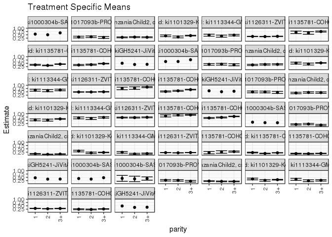

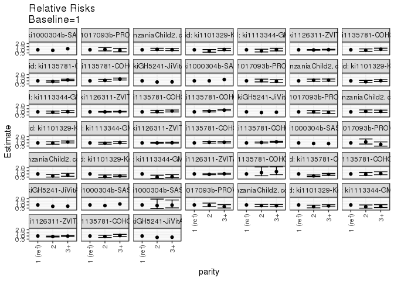

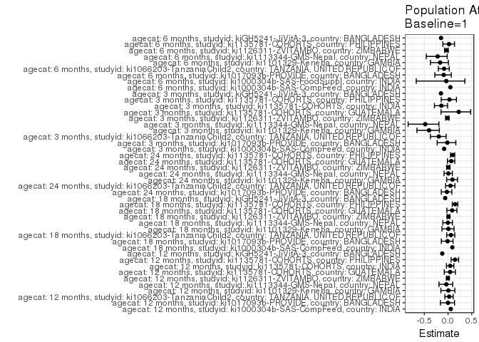

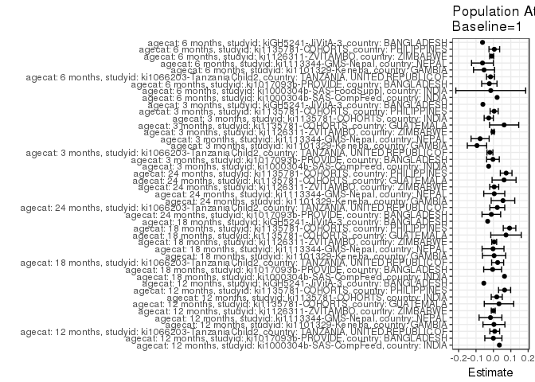

## Results Table

### Parameter: TSM

| agecat | studyid | country | intervention_level | baseline_level | estimate | ci_lower | ci_upper |
| --- | --- | --- | --- | --- | --- | --- | --- |
| 3 months | ki1000304b-SAS-CompFeed | INDIA | 1 | NA | 0.3591549 | NA | NA |
| 3 months | ki1000304b-SAS-CompFeed | INDIA | 2 | NA | 0.3240741 | NA | NA |
| 3 months | ki1000304b-SAS-CompFeed | INDIA | 3+ | NA | 0.3181818 | NA | NA |
| 3 months | ki1017093b-PROVIDE | BANGLADESH | 1 | NA | 0.1881919 | 0.1416224 | 0.2347613 |
| 3 months | ki1017093b-PROVIDE | BANGLADESH | 2 | NA | 0.2172131 | 0.1654371 | 0.2689891 |
| 3 months | ki1017093b-PROVIDE | BANGLADESH | 3+ | NA | 0.1405405 | 0.0904234 | 0.1906577 |
| 3 months | ki1066203-TanzaniaChild2 | TANZANIA, UNITED REPUBLIC OF | 1 | NA | 0.1224732 | 0.1003121 | 0.1446344 |
| 3 months | ki1066203-TanzaniaChild2 | TANZANIA, UNITED REPUBLIC OF | 2 | NA | 0.0815006 | 0.0622090 | 0.1007923 |
| 3 months | ki1066203-TanzaniaChild2 | TANZANIA, UNITED REPUBLIC OF | 3+ | NA | 0.1018767 | 0.0801659 | 0.1235875 |
| 3 months | ki1101329-Keneba | GAMBIA | 1 | NA | 0.3304721 | 0.2700575 | 0.3908867 |
| 3 months | ki1101329-Keneba | GAMBIA | 2 | NA | 0.1979695 | 0.1423113 | 0.2536278 |
| 3 months | ki1101329-Keneba | GAMBIA | 3+ | NA | 0.2255257 | 0.2034616 | 0.2475899 |
| 3 months | ki1113344-GMS-Nepal | NEPAL | 1 | NA | 0.2349398 | 0.1703912 | 0.2994883 |
| 3 months | ki1113344-GMS-Nepal | NEPAL | 2 | NA | 0.1111111 | 0.0612719 | 0.1609503 |
| 3 months | ki1113344-GMS-Nepal | NEPAL | 3+ | NA | 0.1386861 | 0.0977283 | 0.1796439 |
| 3 months | ki1126311-ZVITAMBO | ZIMBABWE | 1 | NA | 0.2123967 | 0.2020901 | 0.2227032 |
| 3 months | ki1126311-ZVITAMBO | ZIMBABWE | 2 | NA | 0.1990950 | 0.1870166 | 0.2111735 |
| 3 months | ki1126311-ZVITAMBO | ZIMBABWE | 3+ | NA | 0.2166094 | 0.2034787 | 0.2297401 |
| 3 months | ki1135781-COHORTS | GUATEMALA | 1 | NA | 0.2125000 | 0.1227714 | 0.3022286 |
| 3 months | ki1135781-COHORTS | GUATEMALA | 2 | NA | 0.2592593 | 0.1637317 | 0.3547868 |
| 3 months | ki1135781-COHORTS | GUATEMALA | 3+ | NA | 0.2917847 | 0.2443171 | 0.3392523 |
| 3 months | ki1135781-COHORTS | INDIA | 1 | NA | 0.2169935 | 0.1877807 | 0.2462062 |
| 3 months | ki1135781-COHORTS | INDIA | 2 | NA | 0.1494755 | 0.1288116 | 0.1701394 |
| 3 months | ki1135781-COHORTS | INDIA | 3+ | NA | 0.2004680 | 0.1849699 | 0.2159661 |
| 3 months | ki1135781-COHORTS | PHILIPPINES | 1 | NA | 0.1403250 | 0.1141576 | 0.1664923 |
| 3 months | ki1135781-COHORTS | PHILIPPINES | 2 | NA | 0.1320755 | 0.1067905 | 0.1573604 |
| 3 months | ki1135781-COHORTS | PHILIPPINES | 3+ | NA | 0.1514793 | 0.1343837 | 0.1685749 |
| 3 months | kiGH5241-JiVitA-3 | BANGLADESH | 1 | NA | 0.4638662 | NA | NA |
| 3 months | kiGH5241-JiVitA-3 | BANGLADESH | 2 | NA | 0.3634525 | NA | NA |
| 3 months | kiGH5241-JiVitA-3 | BANGLADESH | 3+ | NA | 0.3711340 | NA | NA |

[output cut: 105 more lines]

### Parameter: E(Y)

| agecat | studyid | country | intervention_level | baseline_level | estimate | ci_lower | ci_upper |
| --- | --- | --- | --- | --- | --- | --- | --- |
| 3 months | ki1000304b-SAS-CompFeed | INDIA | NA | NA | 0.3319149 | NA | NA |
| 3 months | ki1017093b-PROVIDE | BANGLADESH | NA | NA | 0.1857143 | 0.1568859 | 0.2145427 |
| 3 months | ki1066203-TanzaniaChild2 | TANZANIA, UNITED REPUBLIC OF | NA | NA | 0.1025424 | 0.0903006 | 0.1147841 |
| 3 months | ki1101329-Keneba | GAMBIA | NA | NA | 0.2360420 | 0.2164681 | 0.2556160 |
| 3 months | ki1113344-GMS-Nepal | NEPAL | NA | NA | 0.1585160 | 0.1290957 | 0.1879363 |
| 3 months | ki1126311-ZVITAMBO | ZIMBABWE | NA | NA | 0.2095510 | 0.2028163 | 0.2162856 |
| 3 months | ki1135781-COHORTS | GUATEMALA | NA | NA | 0.2743191 | 0.2357099 | 0.3129282 |
| 3 months | ki1135781-COHORTS | INDIA | NA | NA | 0.1902526 | 0.1787489 | 0.2017563 |
| 3 months | ki1135781-COHORTS | PHILIPPINES | NA | NA | 0.1446335 | 0.1321610 | 0.1571060 |
| 3 months | kiGH5241-JiVitA-3 | BANGLADESH | NA | NA | 0.4034602 | NA | NA |
| 6 months | ki1000304b-SAS-CompFeed | INDIA | NA | NA | 0.4305177 | NA | NA |
| 6 months | ki1000304b-SAS-FoodSuppl | INDIA | NA | NA | 0.4059406 | 0.3096920 | 0.5021892 |
| 6 months | ki1017093b-PROVIDE | BANGLADESH | NA | NA | 0.2546875 | 0.2209066 | 0.2884684 |
| 6 months | ki1066203-TanzaniaChild2 | TANZANIA, UNITED REPUBLIC OF | NA | NA | 0.1996370 | 0.1829452 | 0.2163289 |
| 6 months | ki1101329-Keneba | GAMBIA | NA | NA | 0.3219456 | 0.2999036 | 0.3439876 |
| 6 months | ki1113344-GMS-Nepal | NEPAL | NA | NA | 0.2857143 | 0.2484972 | 0.3229313 |
| 6 months | ki1126311-ZVITAMBO | ZIMBABWE | NA | NA | 0.2945830 | 0.2852170 | 0.3039490 |
| 6 months | ki1135781-COHORTS | PHILIPPINES | NA | NA | 0.2498218 | 0.2338012 | 0.2658424 |
| 6 months | kiGH5241-JiVitA-3 | BANGLADESH | NA | NA | 0.4254743 | NA | NA |
| 12 months | ki1000304b-SAS-CompFeed | INDIA | NA | NA | 0.5882353 | NA | NA |
| 12 months | ki1017093b-PROVIDE | BANGLADESH | NA | NA | 0.3316913 | 0.2942672 | 0.3691154 |
| 12 months | ki1066203-TanzaniaChild2 | TANZANIA, UNITED REPUBLIC OF | NA | NA | 0.3177665 | 0.2972007 | 0.3383323 |
| 12 months | ki1101329-Keneba | GAMBIA | NA | NA | 0.4289709 | 0.4060238 | 0.4519181 |
| 12 months | ki1113344-GMS-Nepal | NEPAL | NA | NA | 0.4553265 | 0.4148326 | 0.4958204 |
| 12 months | ki1126311-ZVITAMBO | ZIMBABWE | NA | NA | 0.3769269 | 0.3675147 | 0.3863390 |
| 12 months | ki1135781-COHORTS | GUATEMALA | NA | NA | 0.7237077 | 0.6866720 | 0.7607433 |
| 12 months | ki1135781-COHORTS | INDIA | NA | NA | 0.4043728 | 0.3897786 | 0.4189671 |
| 12 months | ki1135781-COHORTS | PHILIPPINES | NA | NA | 0.4388125 | 0.4203024 | 0.4573225 |
| 12 months | kiGH5241-JiVitA-3 | BANGLADESH | NA | NA | 0.4516784 | NA | NA |
| 18 months | ki1000304b-SAS-CompFeed | INDIA | NA | NA | 0.6995192 | NA | NA |
| 18 months | ki1017093b-PROVIDE | BANGLADESH | NA | NA | 0.4172185 | 0.3778614 | 0.4565757 |
| 18 months | ki1066203-TanzaniaChild2 | TANZANIA, UNITED REPUBLIC OF | NA | NA | 0.4048780 | 0.3794719 | 0.4302842 |
| 18 months | ki1101329-Keneba | GAMBIA | NA | NA | 0.5224138 | 0.4989374 | 0.5458902 |
| 18 months | ki1113344-GMS-Nepal | NEPAL | NA | NA | 0.6236934 | 0.5840266 | 0.6633602 |
| 18 months | ki1126311-ZVITAMBO | ZIMBABWE | NA | NA | 0.4911438 | 0.4796616 | 0.5026259 |
| 18 months | ki1135781-COHORTS | GUATEMALA | NA | NA | 0.8292683 | 0.7945030 | 0.8640336 |
| 18 months | ki1135781-COHORTS | PHILIPPINES | NA | NA | 0.6166413 | 0.5980630 | 0.6352197 |
| 18 months | kiGH5241-JiVitA-3 | BANGLADESH | NA | NA | 0.5434694 | NA | NA |
| 24 months | ki1017093b-PROVIDE | BANGLADESH | NA | NA | 0.4810997 | 0.4404722 | 0.5217271 |
| 24 months | ki1066203-TanzaniaChild2 | TANZANIA, UNITED REPUBLIC OF | NA | NA | 0.4350581 | 0.4034660 | 0.4666501 |
| 24 months | ki1101329-Keneba | GAMBIA | NA | NA | 0.5901926 | 0.5668966 | 0.6134887 |
| 24 months | ki1113344-GMS-Nepal | NEPAL | NA | NA | 0.6901408 | 0.6520774 | 0.7282042 |
| 24 months | ki1126311-ZVITAMBO | ZIMBABWE | NA | NA | 0.7161874 | 0.6957914 | 0.7365834 |
| 24 months | ki1135781-COHORTS | GUATEMALA | NA | NA | 0.8966245 | 0.8691878 | 0.9240612 |
| 24 months | ki1135781-COHORTS | PHILIPPINES | NA | NA | 0.7525371 | 0.7358238 | 0.7692504 |

### Parameter: RR

| agecat | studyid | country | intervention_level | baseline_level | estimate | ci_lower | ci_upper |
| --- | --- | --- | --- | --- | --- | --- | --- |
| 3 months | ki1000304b-SAS-CompFeed | INDIA | 1 | 1 | 1.0000000 | NA | NA |
| 3 months | ki1000304b-SAS-CompFeed | INDIA | 2 | 1 | 0.9023239 | NA | NA |
| 3 months | ki1000304b-SAS-CompFeed | INDIA | 3+ | 1 | 0.8859180 | NA | NA |
| 3 months | ki1017093b-PROVIDE | BANGLADESH | 1 | 1 | 1.0000000 | 1.0000000 | 1.0000000 |
| 3 months | ki1017093b-PROVIDE | BANGLADESH | 2 | 1 | 1.1542109 | 0.8185904 | 1.6274350 |
| 3 months | ki1017093b-PROVIDE | BANGLADESH | 3+ | 1 | 0.7467939 | 0.4838321 | 1.1526748 |
| 3 months | ki1066203-TanzaniaChild2 | TANZANIA, UNITED REPUBLIC OF | 1 | 1 | 1.0000000 | 1.0000000 | 1.0000000 |
| 3 months | ki1066203-TanzaniaChild2 | TANZANIA, UNITED REPUBLIC OF | 2 | 1 | 0.6654567 | 0.4939963 | 0.8964291 |
| 3 months | ki1066203-TanzaniaChild2 | TANZANIA, UNITED REPUBLIC OF | 3+ | 1 | 0.8318280 | 0.6289549 | 1.1001390 |
| 3 months | ki1101329-Keneba | GAMBIA | 1 | 1 | 1.0000000 | 1.0000000 | 1.0000000 |
| 3 months | ki1101329-Keneba | GAMBIA | 2 | 1 | 0.5990507 | 0.4283714 | 0.8377351 |
| 3 months | ki1101329-Keneba | GAMBIA | 3+ | 1 | 0.6824350 | 0.5546414 | 0.8396733 |
| 3 months | ki1113344-GMS-Nepal | NEPAL | 1 | 1 | 1.0000000 | 1.0000000 | 1.0000000 |
| 3 months | ki1113344-GMS-Nepal | NEPAL | 2 | 1 | 0.4729345 | 0.2794850 | 0.8002828 |
| 3 months | ki1113344-GMS-Nepal | NEPAL | 3+ | 1 | 0.5903051 | 0.3943642 | 0.8835998 |
| 3 months | ki1126311-ZVITAMBO | ZIMBABWE | 1 | 1 | 1.0000000 | 1.0000000 | 1.0000000 |
| 3 months | ki1126311-ZVITAMBO | ZIMBABWE | 2 | 1 | 0.9373735 | 0.8673093 | 1.0130977 |
| 3 months | ki1126311-ZVITAMBO | ZIMBABWE | 3+ | 1 | 1.0198340 | 0.9436412 | 1.1021787 |
| 3 months | ki1135781-COHORTS | GUATEMALA | 1 | 1 | 1.0000000 | 1.0000000 | 1.0000000 |
| 3 months | ki1135781-COHORTS | GUATEMALA | 2 | 1 | 1.2200436 | 0.6966126 | 2.1367779 |
| 3 months | ki1135781-COHORTS | GUATEMALA | 3+ | 1 | 1.3731045 | 0.8733387 | 2.1588599 |
| 3 months | ki1135781-COHORTS | INDIA | 1 | 1 | 1.0000000 | 1.0000000 | 1.0000000 |
| 3 months | ki1135781-COHORTS | INDIA | 2 | 1 | 0.6888480 | 0.5679636 | 0.8354614 |
| 3 months | ki1135781-COHORTS | INDIA | 3+ | 1 | 0.9238436 | 0.7910008 | 1.0789963 |
| 3 months | ki1135781-COHORTS | PHILIPPINES | 1 | 1 | 1.0000000 | 1.0000000 | 1.0000000 |
| 3 months | ki1135781-COHORTS | PHILIPPINES | 2 | 1 | 0.9412115 | 0.7204783 | 1.2295709 |
| 3 months | ki1135781-COHORTS | PHILIPPINES | 3+ | 1 | 1.0794893 | 0.8680719 | 1.3423969 |
| 3 months | kiGH5241-JiVitA-3 | BANGLADESH | 1 | 1 | 1.0000000 | NA | NA |
| 3 months | kiGH5241-JiVitA-3 | BANGLADESH | 2 | 1 | 0.7835286 | NA | NA |
| 3 months | kiGH5241-JiVitA-3 | BANGLADESH | 3+ | 1 | 0.8000885 | NA | NA |

[output cut: 105 more lines]

### Parameter: PAR

| agecat | studyid | country | intervention_level | baseline_level | estimate | ci_lower | ci_upper |
| --- | --- | --- | --- | --- | --- | --- | --- |
| 3 months | ki1000304b-SAS-CompFeed | INDIA | 1 | NA | -0.0272400 | NA | NA |
| 3 months | ki1017093b-PROVIDE | BANGLADESH | 1 | NA | -0.0024776 | -0.0388175 | 0.0338623 |
| 3 months | ki1066203-TanzaniaChild2 | TANZANIA, UNITED REPUBLIC OF | 1 | NA | -0.0199309 | -0.0369882 | -0.0028735 |
| 3 months | ki1101329-Keneba | GAMBIA | 1 | NA | -0.0944301 | -0.1500434 | -0.0388168 |
| 3 months | ki1113344-GMS-Nepal | NEPAL | 1 | NA | -0.0764237 | -0.1283793 | -0.0244682 |
| 3 months | ki1126311-ZVITAMBO | ZIMBABWE | 1 | NA | -0.0028457 | -0.0105897 | 0.0048982 |
| 3 months | ki1135781-COHORTS | GUATEMALA | 1 | NA | 0.0618191 | -0.0220598 | 0.1456979 |
| 3 months | ki1135781-COHORTS | INDIA | 1 | NA | -0.0267408 | -0.0530812 | -0.0004004 |
| 3 months | ki1135781-COHORTS | PHILIPPINES | 1 | NA | 0.0043085 | -0.0188629 | 0.0274800 |
| 3 months | kiGH5241-JiVitA-3 | BANGLADESH | 1 | NA | -0.0604061 | NA | NA |
| 6 months | ki1000304b-SAS-CompFeed | INDIA | 1 | NA | 0.0214268 | NA | NA |
| 6 months | ki1000304b-SAS-FoodSuppl | INDIA | 1 | NA | -0.0151120 | -0.2158944 | 0.1856704 |
| 6 months | ki1017093b-PROVIDE | BANGLADESH | 1 | NA | -0.0233208 | -0.0672780 | 0.0206364 |
| 6 months | ki1066203-TanzaniaChild2 | TANZANIA, UNITED REPUBLIC OF | 1 | NA | -0.0165088 | -0.0396515 | 0.0066339 |
| 6 months | ki1101329-Keneba | GAMBIA | 1 | NA | -0.0536413 | -0.1142546 | 0.0069721 |
| 6 months | ki1113344-GMS-Nepal | NEPAL | 1 | NA | -0.0626728 | -0.1254404 | 0.0000948 |
| 6 months | ki1126311-ZVITAMBO | ZIMBABWE | 1 | NA | -0.0097766 | -0.0211444 | 0.0015913 |
| 6 months | ki1135781-COHORTS | PHILIPPINES | 1 | NA | 0.0052657 | -0.0253911 | 0.0359225 |
| 6 months | kiGH5241-JiVitA-3 | BANGLADESH | 1 | NA | -0.0626437 | NA | NA |
| 12 months | ki1000304b-SAS-CompFeed | INDIA | 1 | NA | 0.0343891 | NA | NA |
| 12 months | ki1017093b-PROVIDE | BANGLADESH | 1 | NA | -0.0001473 | -0.0493868 | 0.0490922 |
| 12 months | ki1066203-TanzaniaChild2 | TANZANIA, UNITED REPUBLIC OF | 1 | NA | 0.0077228 | -0.0202953 | 0.0357410 |
| 12 months | ki1101329-Keneba | GAMBIA | 1 | NA | 0.0031336 | -0.0598890 | 0.0661562 |
| 12 months | ki1113344-GMS-Nepal | NEPAL | 1 | NA | -0.0167232 | -0.0823035 | 0.0488571 |
| 12 months | ki1126311-ZVITAMBO | ZIMBABWE | 1 | NA | -0.0008562 | -0.0121459 | 0.0104334 |
| 12 months | ki1135781-COHORTS | GUATEMALA | 1 | NA | 0.0322183 | -0.0525080 | 0.1169446 |
| 12 months | ki1135781-COHORTS | INDIA | 1 | NA | 0.0192467 | -0.0124159 | 0.0509092 |
| 12 months | ki1135781-COHORTS | PHILIPPINES | 1 | NA | 0.0644448 | 0.0296787 | 0.0992110 |
| 12 months | kiGH5241-JiVitA-3 | BANGLADESH | 1 | NA | -0.0550867 | NA | NA |
| 18 months | ki1000304b-SAS-CompFeed | INDIA | 1 | NA | 0.0638603 | NA | NA |
| 18 months | ki1017093b-PROVIDE | BANGLADESH | 1 | NA | -0.0043061 | -0.0557805 | 0.0471683 |
| 18 months | ki1066203-TanzaniaChild2 | TANZANIA, UNITED REPUBLIC OF | 1 | NA | 0.0244000 | -0.0100617 | 0.0588616 |
| 18 months | ki1101329-Keneba | GAMBIA | 1 | NA | 0.0040892 | -0.0627864 | 0.0709648 |
| 18 months | ki1113344-GMS-Nepal | NEPAL | 1 | NA | -0.0020735 | -0.0650191 | 0.0608721 |
| 18 months | ki1126311-ZVITAMBO | ZIMBABWE | 1 | NA | 0.0046199 | -0.0095194 | 0.0187592 |
| 18 months | ki1135781-COHORTS | GUATEMALA | 1 | NA | 0.0725115 | -0.0149115 | 0.1599346 |
| 18 months | ki1135781-COHORTS | PHILIPPINES | 1 | NA | 0.0929155 | 0.0568404 | 0.1289906 |
| 18 months | kiGH5241-JiVitA-3 | BANGLADESH | 1 | NA | -0.0329672 | NA | NA |
| 24 months | ki1017093b-PROVIDE | BANGLADESH | 1 | NA | -0.0118581 | -0.0653460 | 0.0416299 |
| 24 months | ki1066203-TanzaniaChild2 | TANZANIA, UNITED REPUBLIC OF | 1 | NA | 0.0224075 | -0.0204528 | 0.0652677 |
| 24 months | ki1101329-Keneba | GAMBIA | 1 | NA | 0.0550575 | -0.0127280 | 0.1228430 |
| 24 months | ki1113344-GMS-Nepal | NEPAL | 1 | NA | 0.0049557 | -0.0554594 | 0.0653707 |
| 24 months | ki1126311-ZVITAMBO | ZIMBABWE | 1 | NA | 0.0046756 | -0.0212093 | 0.0305606 |
| 24 months | ki1135781-COHORTS | GUATEMALA | 1 | NA | 0.0613304 | -0.0075818 | 0.1302425 |
| 24 months | ki1135781-COHORTS | PHILIPPINES | 1 | NA | 0.0733256 | 0.0397658 | 0.1068854 |

### Parameter: PAF

| agecat | studyid | country | intervention_level | baseline_level | estimate | ci_lower | ci_upper |
| --- | --- | --- | --- | --- | --- | --- | --- |
| 3 months | ki1000304b-SAS-CompFeed | INDIA | 1 | NA | -0.0820693 | NA | NA |
| 3 months | ki1017093b-PROVIDE | BANGLADESH | 1 | NA | -0.0133409 | -0.2291796 | 0.1645975 |
| 3 months | ki1066203-TanzaniaChild2 | TANZANIA, UNITED REPUBLIC OF | 1 | NA | -0.1943672 | -0.3714954 | -0.0401150 |
| 3 months | ki1101329-Keneba | GAMBIA | 1 | NA | -0.4000563 | -0.6562761 | -0.1834727 |
| 3 months | ki1113344-GMS-Nepal | NEPAL | 1 | NA | -0.4821200 | -0.8421769 | -0.1924368 |
| 3 months | ki1126311-ZVITAMBO | ZIMBABWE | 1 | NA | -0.0135801 | -0.0512157 | 0.0227080 |
| 3 months | ki1135781-COHORTS | GUATEMALA | 1 | NA | 0.2253546 | -0.1485421 | 0.4775329 |
| 3 months | ki1135781-COHORTS | INDIA | 1 | NA | -0.1405544 | -0.2876208 | -0.0102852 |
| 3 months | ki1135781-COHORTS | PHILIPPINES | 1 | NA | 0.0297894 | -0.1443885 | 0.1774571 |
| 3 months | kiGH5241-JiVitA-3 | BANGLADESH | 1 | NA | -0.1497200 | NA | NA |
| 6 months | ki1000304b-SAS-CompFeed | INDIA | 1 | NA | 0.0497699 | NA | NA |
| 6 months | ki1000304b-SAS-FoodSuppl | INDIA | 1 | NA | -0.0372272 | -0.6710312 | 0.3561818 |
| 6 months | ki1017093b-PROVIDE | BANGLADESH | 1 | NA | -0.0915663 | -0.2784251 | 0.0679805 |
| 6 months | ki1066203-TanzaniaChild2 | TANZANIA, UNITED REPUBLIC OF | 1 | NA | -0.0826941 | -0.2049462 | 0.0271544 |
| 6 months | ki1101329-Keneba | GAMBIA | 1 | NA | -0.1666160 | -0.3709750 | 0.0072811 |
| 6 months | ki1113344-GMS-Nepal | NEPAL | 1 | NA | -0.2193548 | -0.4600208 | -0.0183596 |
| 6 months | ki1126311-ZVITAMBO | ZIMBABWE | 1 | NA | -0.0331879 | -0.0725052 | 0.0046881 |
| 6 months | ki1135781-COHORTS | PHILIPPINES | 1 | NA | 0.0210778 | -0.1096572 | 0.1364102 |
| 6 months | kiGH5241-JiVitA-3 | BANGLADESH | 1 | NA | -0.1472328 | NA | NA |
| 12 months | ki1000304b-SAS-CompFeed | INDIA | 1 | NA | 0.0584615 | NA | NA |
| 12 months | ki1017093b-PROVIDE | BANGLADESH | 1 | NA | -0.0004440 | -0.1604731 | 0.1375171 |
| 12 months | ki1066203-TanzaniaChild2 | TANZANIA, UNITED REPUBLIC OF | 1 | NA | 0.0243035 | -0.0679740 | 0.1086077 |
| 12 months | ki1101329-Keneba | GAMBIA | 1 | NA | 0.0073049 | -0.1510396 | 0.1438665 |
| 12 months | ki1113344-GMS-Nepal | NEPAL | 1 | NA | -0.0367280 | -0.1912730 | 0.0977677 |
| 12 months | ki1126311-ZVITAMBO | ZIMBABWE | 1 | NA | -0.0022716 | -0.0326754 | 0.0272370 |
| 12 months | ki1135781-COHORTS | GUATEMALA | 1 | NA | 0.0445184 | -0.0801289 | 0.1547813 |
| 12 months | ki1135781-COHORTS | INDIA | 1 | NA | 0.0475964 | -0.0340187 | 0.1227696 |
| 12 months | ki1135781-COHORTS | PHILIPPINES | 1 | NA | 0.1468619 | 0.0637500 | 0.2225959 |
| 12 months | kiGH5241-JiVitA-3 | BANGLADESH | 1 | NA | -0.1219599 | NA | NA |
| 18 months | ki1000304b-SAS-CompFeed | INDIA | 1 | NA | 0.0912917 | NA | NA |
| 18 months | ki1017093b-PROVIDE | BANGLADESH | 1 | NA | -0.0103210 | -0.1415473 | 0.1058201 |
| 18 months | ki1066203-TanzaniaChild2 | TANZANIA, UNITED REPUBLIC OF | 1 | NA | 0.0602650 | -0.0288506 | 0.1416616 |
| 18 months | ki1101329-Keneba | GAMBIA | 1 | NA | 0.0078275 | -0.1288110 | 0.1279264 |
| 18 months | ki1113344-GMS-Nepal | NEPAL | 1 | NA | -0.0033245 | -0.1094996 | 0.0926899 |
| 18 months | ki1126311-ZVITAMBO | ZIMBABWE | 1 | NA | 0.0094064 | -0.0198052 | 0.0377814 |
| 18 months | ki1135781-COHORTS | GUATEMALA | 1 | NA | 0.0874404 | -0.0248737 | 0.1874462 |
| 18 months | ki1135781-COHORTS | PHILIPPINES | 1 | NA | 0.1506800 | 0.0897894 | 0.2074971 |
| 18 months | kiGH5241-JiVitA-3 | BANGLADESH | 1 | NA | -0.0606607 | NA | NA |
| 24 months | ki1017093b-PROVIDE | BANGLADESH | 1 | NA | -0.0246479 | -0.1421018 | 0.0807271 |
| 24 months | ki1066203-TanzaniaChild2 | TANZANIA, UNITED REPUBLIC OF | 1 | NA | 0.0515046 | -0.0523460 | 0.1451066 |
| 24 months | ki1101329-Keneba | GAMBIA | 1 | NA | 0.0932874 | -0.0292651 | 0.2012477 |
| 24 months | ki1113344-GMS-Nepal | NEPAL | 1 | NA | 0.0071807 | -0.0843382 | 0.0909753 |
| 24 months | ki1126311-ZVITAMBO | ZIMBABWE | 1 | NA | 0.0065285 | -0.0302817 | 0.0420236 |
| 24 months | ki1135781-COHORTS | GUATEMALA | 1 | NA | 0.0684014 | -0.0121834 | 0.1425704 |
| 24 months | ki1135781-COHORTS | PHILIPPINES | 1 | NA | 0.0974379 | 0.0514752 | 0.1411733 |